# Example - Ice Cream Ratings

Commercially produced ice cream is made from a mixture of ingredients: a minimum of 10% milk fat, 9—12% milk solids, 12—16% sweetener, 0.2—0.5% stabilizers and emulsifiers, and 55—64% water. Air is incorporated with the above ingredients during the mixing process. The finest ice creams have between 3% and 15% air.

A food scientist is investigating how varying the amounts of the above ingredients impacts the sensory rating of the final product. The scientist decides to use three levels of milk fat: 10%, 12%, and 15%; three amounts of air: 5%, 10%, 15%; and two levels of sweeteners: 12%, 16%.

## Categorical Predictors

#### Create Dummy Variables

```r
data <- dummy_cols(data, select_columns = c("Sweetner", "MilkFat", "Air"))
```

#### Construct the Model with All Main Effects

```r
m <- lm(Ratings ~ Sweetner_12 + MilkFat_12 + MilkFat_15 + Air_10 + Air_15, data = data)
summary(m)
```

```
##
## Call:
## lm(formula = Ratings ~ Sweetner_12 + MilkFat_12 + MilkFat_15 +
##     Air_10 + Air_15, data = data)
##
## Residuals:
##     Min      1Q  Median      3Q     Max
## -5.8148 -2.6759  0.2222  2.8519  8.5926
##
## Coefficients:
##             Estimate Std. Error t value Pr(>|t|)
## (Intercept)  28.4074     1.1882  23.908  < 2e-16 ***
## Sweetner_12  -1.9259     0.9702  -1.985   0.0529 .
## MilkFat_12    5.3333     1.1882   4.489 4.49e-05 ***
## MilkFat_15    2.0000     1.1882   1.683   0.0988 .
## Air_10        5.6667     1.1882   4.769 1.76e-05 ***
## Air_15       -0.6667     1.1882  -0.561   0.5774
## ---
## Signif. codes:  0 '***' 0.001 '**' 0.01 '*' 0.05 '.' 0.1 ' ' 1
##
## Residual standard error: 3.565 on 48 degrees of freedom
## Multiple R-squared:  0.5506, Adjusted R-squared:  0.5038
## F-statistic: 11.76 on 5 and 48 DF,  p-value: 1.88e-07
```

#### Is Sweetner a Significant Predictor of Sensory Rating?

```r
tidy(m)$p.value[2]
```

```
## [1] 0.05286039
```

**Hypotheses**

$H_0: \ \beta_{\text{Sweetner}} = 0$  
$H_1: \ \beta_{\text{Sweetner}} \ne 0$

**Test Statistic**

$t_0 = -1.9851$

*p*-value

$p = 0.0529$

**Rejection Region**

Reject $H_0$ if $p < \alpha$; $\alpha = 0.05$.

**Conclusion and Interpretation**

FTR $H_0$. There is not sufficient evidence to suggest that sweetener is a predictor of sensory rating.

#### Is Milk Fat a Significant Predictor of Sensory Rating?

```r
full <- lm(Ratings ~ Sweetner_12 + MilkFat_12 + MilkFat_15 + Air_10 + Air_15, data = data)
reduced <- lm(Ratings ~ Sweetner_12 + Air_10 + Air_15, data = data)
(anova1 <- anova(reduced, full))
```

```
## Analysis of Variance Table
##
## Model 1: Ratings ~ Sweetner_12 + Air_10 + Air_15
## Model 2: Ratings ~ Sweetner_12 + MilkFat_12 + MilkFat_15 + Air_10 + Air_15
##   Res.Df    RSS Df Sum of Sq      F    Pr(>F)
## 1     50 871.26
## 2     48 609.93  2    261.33 10.283 0.0001919 ***
## ---
## Signif. codes:  0 '***' 0.001 '**' 0.01 '*' 0.05 '.' 0.1 ' ' 1
```

**Hypotheses**

$H_0: \ \beta_{\text{MilkFat12}} = \beta_{\text{MilkFat15}} = 0$

$H_1:$ at least one $\beta_i$ is $\ne 0$

**Test Statistic**

$F_0 = 10.2832$

*p*-value

$F_0 = 2\times 10^{-4}$

**Rejection Region**

Reject $H_0$ if $p < \alpha$; $\alpha = 0.05$

**Conclusion and Interpretation**

Reject $H_0$. There is sufficient evidence to suggest that milk fat is a significant predictor of sensory rating.

#### Is Air a Significant Predictor of Sensory Rating?

```r
full <- lm(Ratings ~ Sweetner_12 + MilkFat_12 + MilkFat_15 + Air_10 + Air_15, data = data)
reduced <- lm(Ratings ~ Sweetner_12 + MilkFat_12 + MilkFat_15, data = data)
(anova2 <- anova(reduced, full))
```

```
## Analysis of Variance Table
##
## Model 1: Ratings ~ Sweetner_12 + MilkFat_12 + MilkFat_15
## Model 2: Ratings ~ Sweetner_12 + MilkFat_12 + MilkFat_15 + Air_10 + Air_15
##   Res.Df     RSS Df Sum of Sq      F    Pr(>F)
## 1     50 1045.93
## 2     48  609.93  2       436 17.156 2.391e-06 ***
## ---
## Signif. codes:  0 '***' 0.001 '**' 0.01 '*' 0.05 '.' 0.1 ' ' 1
```

**Hypotheses**

$H_0: \ \beta_{\text{Air10}} = \beta_{\text{Air15}} = 0$ $H_1:$ at least one $\beta_i$ is $\ne 0$

**Test Statistic**

$F_0 = 17.1562$

*p*-value

$F_0 = 0$

**Rejection Region**

Reject $H_0$ if $p < \alpha$; $\alpha = 0.05$

**Conclusion and Interpretation**

Reject $H_0$. There is sufficient evidence to suggest that air is a significant predictor of sensory rating.

## Visualization - Categorical Predictors Only

We have a model with three categorical predictors. Ratings will go on the Y axis. This is always the outcome of interest. Milk fat will go on the X axis. This should be something we can treat as continuous; if you have multiple to choose from, choose the one with the most categories. We can combine the other two predictors (air and sweetener) to create lines: - Air 5, Sweetener 12 - Air 5, Sweetener 16 - Air 10, Sweetener 12 - Air 10, Sweetener 16 - Air 15, Sweetener 12 - Air 15, Sweetener 16

```r
c <- coefficients(m)
c
```

```
## (Intercept) Sweetner_12  MilkFat_12  MilkFat_15      Air_10      Air_15
##  28.4074074  -1.9259259   5.3333333   2.0000000   5.6666667  -0.6666667
```

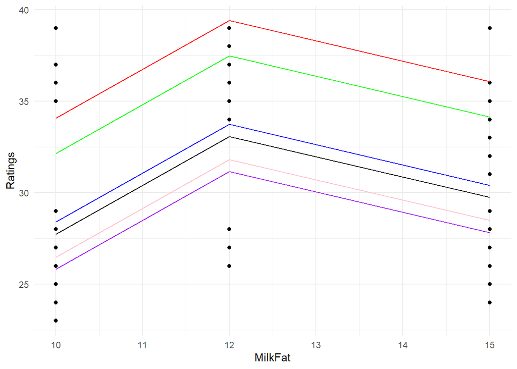

```r
data <- data %>%
  mutate(y_s12_a5 = c["(Intercept)"] + c["Sweetner_12"]*1 + c["MilkFat_12"]*MilkFat_12 + c["MilkFat_15"]*MilkFat_15 +
           c["Air_10"]*0 + c["Air_15"]*0,
         y_s16_a5 = c["(Intercept)"] + c["Sweetner_12"]*0 + c["MilkFat_12"]*MilkFat_12 + c["MilkFat_15"]*MilkFat_15 +
           c["Air_10"]*0 + c["Air_15"]*0,
         y_s12_a10 = c["(Intercept)"] + c["Sweetner_12"]*1 + c["MilkFat_12"]*MilkFat_12 + c["MilkFat_15"]*MilkFat_15 +
           c["Air_10"]*1 + c["Air_15"]*0,
         y_s16_a10 = c["(Intercept)"] + c["Sweetner_12"]*0 + c["MilkFat_12"]*MilkFat_12 + c["MilkFat_15"]*MilkFat_15 +
           c["Air_10"]*1 + c["Air_15"]*0,
         y_s12_a15 = c["(Intercept)"] + c["Sweetner_12"]*1 + c["MilkFat_12"]*MilkFat_12 + c["MilkFat_15"]*MilkFat_15 +
           c["Air_10"]*0 + c["Air_15"]*1,
         y_s16_a15 = c["(Intercept)"] + c["Sweetner_12"]*0 + c["MilkFat_12"]*MilkFat_12 + c["MilkFat_15"]*MilkFat_15 +
           c["Air_10"]*0 + c["Air_15"]*1)
data %>% ggplot(aes(x = MilkFat, y = Ratings)) +
  geom_point() +
  geom_line(aes(y = y_s12_a5), color = "pink") +
  geom_line(aes(y = y_s16_a5), color = "blue") +
  geom_line(aes(y = y_s12_a10), color = "green") +
  geom_line(aes(y = y_s16_a10), color = "red") +
  geom_line(aes(y = y_s12_a15), color = "purple") +
  geom_line(aes(y = y_s16_a15)) +
  theme_minimal()
```

## Continuous Predictors

#### Construct the Model with All Main Effects

#### Is Sweetner a Significant Predictor of Sensory Rating?

```r
m <- lm(Ratings ~ Sweetner_16 + MilkFat_12 + MilkFat_15 + Air_10 + Air_15 +
        Sweetner_16:MilkFat_12 + Sweetner_16:MilkFat_15 +
          Sweetner_16:Air_10 + Sweetner_16:Air_15 +
          MilkFat_12:Air_10 + MilkFat_12:Air_15 +
          MilkFat_15:Air_10 + MilkFat_15:Air_15 +
          Sweetner_16:MilkFat_15:Air_15 +
          Sweetner_16:MilkFat_15:Air_10 +
          Sweetner_16:MilkFat_12:Air_15 +
          Sweetner_16:MilkFat_12:Air_10, data = data)
summary(m)
```

```
##
## Call:
## lm(formula = Ratings ~ Sweetner_16 + MilkFat_12 + MilkFat_15 +
##     Air_10 + Air_15 + Sweetner_16:MilkFat_12 + Sweetner_16:MilkFat_15 +
##     Sweetner_16:Air_10 + Sweetner_16:Air_15 + MilkFat_12:Air_10 +
##     MilkFat_12:Air_15 + MilkFat_15:Air_10 + MilkFat_15:Air_15 +
##     Sweetner_16:MilkFat_15:Air_15 + Sweetner_16:MilkFat_15:Air_10 +
##     Sweetner_16:MilkFat_12:Air_15 + Sweetner_16:MilkFat_12:Air_10,
##     data = data)
##
## Residuals:
##    Min     1Q Median     3Q    Max
##     -3     -1      0      1      3
##
## Coefficients:
##                               Estimate Std. Error t value Pr(>|t|)
## (Intercept)                    24.0000     1.0453  22.961  < 2e-16 ***
## Sweetner_16                     1.0000     1.4782   0.676 0.503059
## MilkFat_12                      3.0000     1.4782   2.029 0.049856 *
## MilkFat_15                      6.6667     1.4782   4.510 6.65e-05 ***
## Air_10                         11.6667     1.4782   7.892 2.30e-09 ***
## Air_15                          2.3333     1.4782   1.578 0.123209
## Sweetner_16:MilkFat_12          8.3333     2.0905   3.986 0.000314 ***
## Sweetner_16:MilkFat_15          4.6667     2.0905   2.232 0.031909 *
## Sweetner_16:Air_10              0.3333     2.0905   0.159 0.874207
## Sweetner_16:Air_15             -0.6667     2.0905  -0.319 0.751648
## MilkFat_12:Air_10              -1.6667     2.0905  -0.797 0.430538
## MilkFat_12:Air_15               5.3333     2.0905   2.551 0.015130 *
## MilkFat_15:Air_10              -8.3333     2.0905  -3.986 0.000314 ***
## MilkFat_15:Air_15              -7.0000     2.0905  -3.348 0.001915 **
## Sweetner_16:MilkFat_15:Air_15  -5.0000     2.9565  -1.691 0.099439 .
## Sweetner_16:MilkFat_15:Air_10  -6.3333     2.9565  -2.142 0.039015 *
## Sweetner_16:MilkFat_12:Air_15  -7.6667     2.9565  -2.593 0.013661 *
## Sweetner_16:MilkFat_12:Air_10 -10.6667     2.9565  -3.608 0.000930 ***
## ---
## Signif. codes:  0 '***' 0.001 '**' 0.01 '*' 0.05 '.' 0.1 ' ' 1
##
## Residual standard error: 1.81 on 36 degrees of freedom
## Multiple R-squared:  0.9131, Adjusted R-squared:  0.872
## F-statistic: 22.24 on 17 and 36 DF,  p-value: 3.701e-14
```

#### Testing the Three-Way Interaction Between Sweetner, Milk Fat, and Air

```r
full <- lm(Ratings ~ Sweetner_16 + MilkFat_12 + MilkFat_15 + Air_10 + Air_15 +
        Sweetner_16:MilkFat_12 + Sweetner_16:MilkFat_15 +
          Sweetner_16:Air_10 + Sweetner_16:Air_15 +
          MilkFat_12:Air_10 + MilkFat_12:Air_15 +
          MilkFat_15:Air_10 + MilkFat_15:Air_15 +
          Sweetner_16:MilkFat_15:Air_15 +
          Sweetner_16:MilkFat_15:Air_10 +
          Sweetner_16:MilkFat_12:Air_15 +
          Sweetner_16:MilkFat_12:Air_10, data = data)
reduced <- lm(Ratings ~ Sweetner_16 + MilkFat_12 + MilkFat_15 + Air_10 + Air_15 +
        Sweetner_16:MilkFat_12 + Sweetner_16:MilkFat_15 +
          Sweetner_16:Air_10 + Sweetner_16:Air_15 +
          MilkFat_12:Air_10 + MilkFat_12:Air_15 +
          MilkFat_15:Air_10 + MilkFat_15:Air_15, data = data)
anova(reduced, full)
```

```
## Analysis of Variance Table
##
## Model 1: Ratings ~ Sweetner_16 + MilkFat_12 + MilkFat_15 + Air_10 + Air_15 +
##     Sweetner_16:MilkFat_12 + Sweetner_16:MilkFat_15 + Sweetner_16:Air_10 +
##     Sweetner_16:Air_15 + MilkFat_12:Air_10 + MilkFat_12:Air_15 +
##     MilkFat_15:Air_10 + MilkFat_15:Air_15
## Model 2: Ratings ~ Sweetner_16 + MilkFat_12 + MilkFat_15 + Air_10 + Air_15 +
##     Sweetner_16:MilkFat_12 + Sweetner_16:MilkFat_15 + Sweetner_16:Air_10 +
##     Sweetner_16:Air_15 + MilkFat_12:Air_10 + MilkFat_12:Air_15 +
##     MilkFat_15:Air_10 + MilkFat_15:Air_15 + Sweetner_16:MilkFat_15:Air_15 +
##     Sweetner_16:MilkFat_15:Air_10 + Sweetner_16:MilkFat_12:Air_15 +
##     Sweetner_16:MilkFat_12:Air_10
##   Res.Df    RSS Df Sum of Sq      F  Pr(>F)
## 1     40 164.19
## 2     36 118.00  4    46.185 3.5226 0.01587 *
## ---
## Signif. codes:  0 '***' 0.001 '**' 0.01 '*' 0.05 '.' 0.1 ' ' 1
```

```r
m <- lm(Ratings ~ Sweetner + MilkFat + Air + Sweetner:MilkFat + Sweetner:Air + MilkFat:Air + Sweetner:MilkFat:Air, data = data)
m <- lm(Ratings ~ Sweetner*MilkFat*Air, data = data)
summary(m)
```

```
##
## Call:
## lm(formula = Ratings ~ Sweetner * MilkFat * Air, data = data)
##
## Residuals:
##     Min      1Q  Median      3Q     Max
## -8.8596 -3.4152  0.0643  3.4401  8.4795
##
## Coefficients:
##                      Estimate Std. Error t value Pr(>|t|)
## (Intercept)          22.03801   74.56206   0.296    0.769
## Sweetner             -1.31652    5.27233  -0.250    0.804
## MilkFat              -1.10819    5.96337  -0.186    0.853
## Air                   0.48684    6.90311   0.071    0.944
## Sweetner:MilkFat      0.24488    0.42167   0.581    0.564
## Sweetner:Air          0.14013    0.48812   0.287    0.775
## MilkFat:Air           0.09386    0.55210   0.170    0.866
## Sweetner:MilkFat:Air -0.02127    0.03904  -0.545    0.588
##
## Residual standard error: 4.813 on 46 degrees of freedom
## Multiple R-squared:  0.2149, Adjusted R-squared:  0.09543
## F-statistic: 1.799 on 7 and 46 DF,  p-value: 0.1104
```

#### Testing the Three-Way Interaction Between Sweetner, Milk Fat, and Air

```r
m <- lm(Ratings ~ Sweetner + MilkFat + Air + Sweetner:MilkFat + Sweetner:Air + MilkFat:Air, data = data)
summary(m)
```

```
##
## Call:
## lm(formula = Ratings ~ Sweetner + MilkFat + Air + Sweetner:MilkFat +
##     Sweetner:Air + MilkFat:Air, data = data)
##
## Residuals:
##     Min      1Q  Median      3Q     Max
## -9.3560 -3.3273 -0.2193  3.4313  8.4795
##
## Coefficients:
##                   Estimate Std. Error t value Pr(>|t|)
## (Intercept)      -14.69152   31.62993  -0.464  0.64445
## Sweetner           1.30702    2.13203   0.613  0.54281
## MilkFat            1.86988    2.36744   0.790  0.43359
## Air                4.15980    1.47689   2.817  0.00707 **
## Sweetner:MilkFat   0.03216    0.15818   0.203  0.83975
## Sweetner:Air      -0.12222    0.07962  -1.535  0.13145
## MilkFat:Air       -0.20395    0.07749  -2.632  0.01145 *
## ---
## Signif. codes:  0 '***' 0.001 '**' 0.01 '*' 0.05 '.' 0.1 ' ' 1
##
## Residual standard error: 4.777 on 47 degrees of freedom
## Multiple R-squared:  0.2098, Adjusted R-squared:  0.109
## F-statistic:  2.08 on 6 and 47 DF,  p-value: 0.07345
```

#### Test Significance of All Interaction Terms

Can we remove the non-significant interactions at the same time?

```r
full <- lm(Ratings ~ Sweetner + MilkFat + Air + Sweetner:MilkFat + Sweetner:Air + MilkFat:Air, data = data)
reduced <- lm(Ratings ~ Sweetner + MilkFat + Air + MilkFat:Air, data = data)
anova(reduced, full)
```

```
## Analysis of Variance Table
##
## Model 1: Ratings ~ Sweetner + MilkFat + Air + MilkFat:Air
## Model 2: Ratings ~ Sweetner + MilkFat + Air + Sweetner:MilkFat + Sweetner:Air +
##     MilkFat:Air
##   Res.Df    RSS Df Sum of Sq     F Pr(>F)
## 1     49 1127.2
## 2     47 1072.5  2    54.721 1.199 0.3105
```

```r
summary(m)
```

```
##
## Call:
## lm(formula = Ratings ~ Sweetner + MilkFat + Air + Sweetner:MilkFat +
##     Sweetner:Air + MilkFat:Air, data = data)
##
## Residuals:
##     Min      1Q  Median      3Q     Max
## -9.3560 -3.3273 -0.2193  3.4313  8.4795
##
## Coefficients:
##                   Estimate Std. Error t value Pr(>|t|)
## (Intercept)      -14.69152   31.62993  -0.464  0.64445
## Sweetner           1.30702    2.13203   0.613  0.54281
## MilkFat            1.86988    2.36744   0.790  0.43359
## Air                4.15980    1.47689   2.817  0.00707 **
## Sweetner:MilkFat   0.03216    0.15818   0.203  0.83975
## Sweetner:Air      -0.12222    0.07962  -1.535  0.13145
## MilkFat:Air       -0.20395    0.07749  -2.632  0.01145 *
## ---
## Signif. codes:  0 '***' 0.001 '**' 0.01 '*' 0.05 '.' 0.1 ' ' 1
##
## Residual standard error: 4.777 on 47 degrees of freedom
## Multiple R-squared:  0.2098, Adjusted R-squared:  0.109
## F-statistic:  2.08 on 6 and 47 DF,  p-value: 0.07345
```

```r
m <- lm(Ratings ~ Sweetner + MilkFat + Air + MilkFat:Air, data = data)
summary(m)
```

```
##
## Call:
## lm(formula = Ratings ~ Sweetner + MilkFat + Air + MilkFat:Air,
##     data = data)
##
## Residuals:
##     Min      1Q  Median      3Q     Max
## -8.9096 -3.7918  0.2066  3.5800  8.5010
##
## Coefficients:
##             Estimate Std. Error t value Pr(>|t|)
## (Intercept) -3.13402   11.45823  -0.274  0.78561
## Sweetner     0.48148    0.32635   1.475  0.14651
## MilkFat      2.32018    0.84041   2.761  0.00809 **
## Air          2.44868    0.97284   2.517  0.01516 *
## MilkFat:Air -0.20395    0.07781  -2.621  0.01164 *
## ---
## Signif. codes:  0 '***' 0.001 '**' 0.01 '*' 0.05 '.' 0.1 ' ' 1
##
## Residual standard error: 4.796 on 49 degrees of freedom
## Multiple R-squared:  0.1695, Adjusted R-squared:  0.1017
## F-statistic: 2.501 on 4 and 49 DF,  p-value: 0.0544
```

Is there anything else we can remove?

```r
m <- lm(Ratings ~  MilkFat + Air + MilkFat:Air, data = data)
```

#### Final Model

```r
m <- lm(Ratings ~  MilkFat + Air + MilkFat:Air, data = data)
summary(m)
```

```
##
## Call:
## lm(formula = Ratings ~ MilkFat + Air + MilkFat:Air, data = data)
##
## Residuals:
##     Min      1Q  Median      3Q     Max
## -8.9466 -4.3304  0.6696  3.9985  8.0994
##
## Coefficients:
##             Estimate Std. Error t value Pr(>|t|)
## (Intercept)  3.60673   10.63084   0.339  0.73583
## MilkFat      2.32018    0.85024   2.729  0.00875 **
## Air          2.44868    0.98422   2.488  0.01623 *
## MilkFat:Air -0.20395    0.07872  -2.591  0.01251 *
## ---
## Signif. codes:  0 '***' 0.001 '**' 0.01 '*' 0.05 '.' 0.1 ' ' 1
##
## Residual standard error: 4.852 on 50 degrees of freedom
## Multiple R-squared:  0.1326, Adjusted R-squared:  0.08059
## F-statistic: 2.549 on 3 and 50 DF,  p-value: 0.06625
```

## Visualization - Interaction

We will use levels 5, 10, and 15 in our predictions. Note that if this were truly a continuous variable, we would want to look at the 25th percentile, the median, and the 75th percentile.

We will use levels 10, 12, and 15 in our predictions. Like we noted for air, if this were truly a continuous variable, we would want to look at the 25th percentile, the median, and the 75th percentile.